# Pandas Tutorial

https://github.com/bofethe/pandas-tutorial

August 2022

[figure not shown]

Data stored in pandas can be accessed and edited much faster than a python list for many reasons, but one reason behind this is pandas allows vectorizing operations where you can apply a function to an entire series as a whole in 1 sweep as opposed to iterating over each element in a list and applying a function one-by-one. Similar to pandas, numpy also increases performance as discussed at [this link](https://towardsdatascience.com/speed-testing-pandas-vs-numpy-ffbf80070ee7) on towardsdatascience. The 2 main structures of pandas include a series and a dataframe. A series is 1 individual column often shorthanded as `s` while a dataframe is a set of series often shorthanded as `df`.

```python
import pandas as pd
import numpy as np
```

## Getting Started

To get started, you can create a dataframe using built-in pandas methods like `DataFrame()` and passing a dictionary with it's values as a list. Note that the length of the lists must match or you'll throw a `ValueError`.

```python
df = pd.DataFrame({'col1':[1,2,3], 'col2':[4,5,6], 'col3':[7,8,9]})
df
```

|  | col1 | col2 | col3 |
| --- | --- | --- | --- |
| 0 | 1 | 4 | 7 |
| 1 | 2 | 5 | 8 |
| 2 | 3 | 6 | 9 |

More commonly, you can import spreadsheets as dataframes using `read_excel()` or `read_csv()`. If you want to return the top or bottom *n* rows of your dataset, you can use `df.head(n)` or `df.tail(n)`, respectively with a default *n* = 5.

```python
df = pd.read_csv('avocado.csv')
df.head()
```

|  | Unnamed: 0 | Date | AveragePrice | Total Volume | 4046 | 4225 | 4770 | Total Bags | Small Bags | Large Bags | XLarge Bags | type | year | region |
| --- | --- | --- | --- | --- | --- | --- | --- | --- | --- | --- | --- | --- | --- | --- |
| 0 | 0 | 2015-12-27 | 1.33 | 64236.62 | 1036.74 | 54454.85 | 48.16 | 8696.87 | 8603.62 | 93.25 | 0.0 | conventional | 2015 | Albany |
| 1 | 1 | 2015-12-20 | 1.35 | 54876.98 | 674.28 | 44638.81 | 58.33 | 9505.56 | 9408.07 | 97.49 | 0.0 | conventional | 2015 | Albany |
| 2 | 2 | 2015-12-13 | 0.93 | 118220.22 | 794.70 | 109149.67 | 130.50 | 8145.35 | 8042.21 | 103.14 | 0.0 | conventional | 2015 | Albany |
| 3 | 3 | 2015-12-06 | 1.08 | 78992.15 | 1132.00 | 71976.41 | 72.58 | 5811.16 | 5677.40 | 133.76 | 0.0 | conventional | 2015 | Albany |
| 4 | 4 | 2015-11-29 | 1.28 | 51039.60 | 941.48 | 43838.39 | 75.78 | 6183.95 | 5986.26 | 197.69 | 0.0 | conventional | 2015 | Albany |

Show the series names and the associated types using `df.dtypes`.

```python
df.dtypes
```

```
Unnamed: 0        int64
Date             object
AveragePrice    float64
Total Volume    float64
4046            float64
4225            float64
4770            float64
Total Bags      float64
Small Bags      float64
Large Bags      float64
XLarge Bags     float64
type             object
year              int64
region           object
dtype: object
```

One thing to note about the dtypes is that the dtype object can be strings or a mix of different types. In this case, the `Date` series read in as a string from the csv import, so we can cast that series to it's appropraite dtype using `s.astype()`. Alternatively, you can use `df.astype(d)` where `d` is a dictionary map of the series names and types you wish to cast.

```python
df['Date'] = df['Date'].astype('datetime64')
df.dtypes
```

```
Unnamed: 0               int64
Date            datetime64[ns]
AveragePrice           float64
Total Volume           float64
4046                   float64
4225                   float64
4770                   float64
Total Bags             float64
Small Bags             float64
Large Bags             float64
XLarge Bags            float64
type                    object
year                     int64
region                  object
dtype: object
```

If you're only interested in the shape, you can use `df.shape` to return a tuple containing the matrix shape in the form of (*rows*, *columns*). This is useful when making sure the shape of two large dataframes match when manual checking isn't a feasible option.

```python
df.shape
```

```
(18249, 14)
```

Series are accessed by passing the series's name in `[]` or a list of names.

```python
df['Date']
```

```
0       2015-12-27
1       2015-12-20
2       2015-12-13
3       2015-12-06
4       2015-11-29
           ...
18244   2018-02-04
18245   2018-01-28
18246   2018-01-21
18247   2018-01-14
18248   2018-01-07
Name: Date, Length: 18249, dtype: datetime64[ns]
```

```python
df[['Date', 'Total Volume', 'AveragePrice']].head()
```

|  | Date | Total Volume | AveragePrice |
| --- | --- | --- | --- |
| 0 | 2015-12-27 | 64236.62 | 1.33 |
| 1 | 2015-12-20 | 54876.98 | 1.35 |
| 2 | 2015-12-13 | 118220.22 | 0.93 |
| 3 | 2015-12-06 | 78992.15 | 1.08 |
| 4 | 2015-11-29 | 51039.60 | 1.28 |

You can also pass in a boolean to access datapoints that would return `True` for a statement.

```python
df[df['Date'] > '2018-01-01']
```

|  | Unnamed: 0 | Date | AveragePrice | Total Volume | 4046 | 4225 | 4770 | Total Bags | Small Bags | Large Bags | XLarge Bags | type | year | region |
| --- | --- | --- | --- | --- | --- | --- | --- | --- | --- | --- | --- | --- | --- | --- |
| 8478 | 0 | 2018-03-25 | 1.57 | 149396.50 | 16361.69 | 109045.03 | 65.45 | 23924.33 | 19273.80 | 4270.53 | 380.00 | conventional | 2018 | Albany |
| 8479 | 1 | 2018-03-18 | 1.35 | 105304.65 | 13234.86 | 61037.58 | 55.00 | 30977.21 | 26755.90 | 3721.31 | 500.00 | conventional | 2018 | Albany |
| 8480 | 2 | 2018-03-11 | 1.12 | 144648.75 | 15823.35 | 110950.68 | 70.00 | 17804.72 | 14480.52 | 3033.09 | 291.11 | conventional | 2018 | Albany |
| 8481 | 3 | 2018-03-04 | 1.08 | 139520.60 | 12002.12 | 105069.57 | 95.62 | 22353.29 | 16128.51 | 5941.45 | 283.33 | conventional | 2018 | Albany |
| 8482 | 4 | 2018-02-25 | 1.28 | 104278.89 | 10368.77 | 59723.32 | 48.00 | 34138.80 | 30126.31 | 3702.49 | 310.00 | conventional | 2018 | Albany |
| ... | ... | ... | ... | ... | ... | ... | ... | ... | ... | ... | ... | ... | ... | ... |
| 18244 | 7 | 2018-02-04 | 1.63 | 17074.83 | 2046.96 | 1529.20 | 0.00 | 13498.67 | 13066.82 | 431.85 | 0.00 | organic | 2018 | WestTexNewMexico |
| 18245 | 8 | 2018-01-28 | 1.71 | 13888.04 | 1191.70 | 3431.50 | 0.00 | 9264.84 | 8940.04 | 324.80 | 0.00 | organic | 2018 | WestTexNewMexico |
| 18246 | 9 | 2018-01-21 | 1.87 | 13766.76 | 1191.92 | 2452.79 | 727.94 | 9394.11 | 9351.80 | 42.31 | 0.00 | organic | 2018 | WestTexNewMexico |
| 18247 | 10 | 2018-01-14 | 1.93 | 16205.22 | 1527.63 | 2981.04 | 727.01 | 10969.54 | 10919.54 | 50.00 | 0.00 | organic | 2018 | WestTexNewMexico |
| 18248 | 11 | 2018-01-07 | 1.62 | 17489.58 | 2894.77 | 2356.13 | 224.53 | 12014.15 | 11988.14 | 26.01 | 0.00 | organic | 2018 | WestTexNewMexico |

1296 rows × 14 columns

2 useful methods to see basic metrics for a dataframe or series is by calling `df.describe()` for the statistics on the numerical fields, or you use `df.nunique()` to see how many unique options are available in each series.

```python
df.describe()
```

|  | Unnamed: 0 | AveragePrice | Total Volume | 4046 | 4225 | 4770 | Total Bags | Small Bags | Large Bags | XLarge Bags | year |
| --- | --- | --- | --- | --- | --- | --- | --- | --- | --- | --- | --- |
| count | 18249.000000 | 18249.000000 | 1.824900e+04 | 1.824900e+04 | 1.824900e+04 | 1.824900e+04 | 1.824900e+04 | 1.824900e+04 | 1.824900e+04 | 18249.000000 | 18249.000000 |
| mean | 24.232232 | 1.405978 | 8.506440e+05 | 2.930084e+05 | 2.951546e+05 | 2.283974e+04 | 2.396392e+05 | 1.821947e+05 | 5.433809e+04 | 3106.426507 | 2016.147899 |
| std | 15.481045 | 0.402677 | 3.453545e+06 | 1.264989e+06 | 1.204120e+06 | 1.074641e+05 | 9.862424e+05 | 7.461785e+05 | 2.439660e+05 | 17692.894652 | 0.939938 |
| min | 0.000000 | 0.440000 | 8.456000e+01 | 0.000000e+00 | 0.000000e+00 | 0.000000e+00 | 0.000000e+00 | 0.000000e+00 | 0.000000e+00 | 0.000000 | 2015.000000 |
| 25% | 10.000000 | 1.100000 | 1.083858e+04 | 8.540700e+02 | 3.008780e+03 | 0.000000e+00 | 5.088640e+03 | 2.849420e+03 | 1.274700e+02 | 0.000000 | 2015.000000 |
| 50% | 24.000000 | 1.370000 | 1.073768e+05 | 8.645300e+03 | 2.906102e+04 | 1.849900e+02 | 3.974383e+04 | 2.636282e+04 | 2.647710e+03 | 0.000000 | 2016.000000 |
| 75% | 38.000000 | 1.660000 | 4.329623e+05 | 1.110202e+05 | 1.502069e+05 | 6.243420e+03 | 1.107834e+05 | 8.333767e+04 | 2.202925e+04 | 132.500000 | 2017.000000 |
| max | 52.000000 | 3.250000 | 6.250565e+07 | 2.274362e+07 | 2.047057e+07 | 2.546439e+06 | 1.937313e+07 | 1.338459e+07 | 5.719097e+06 | 551693.650000 | 2018.000000 |

```python
df.nunique()
```

```
Unnamed: 0         53
Date              169
AveragePrice      259
Total Volume    18237
4046            17702
4225            18103
4770            12071
Total Bags      18097
Small Bags      17321
Large Bags      15082
XLarge Bags      5588
type                2
year                4
region             54
dtype: int64
```

If you want to see statistics for a given value in the data use the `df.groupby()` followed by what type of calculation you are interested in. You can also sort the dataframe using `df.sort_values()`. In the event of a tie, you can pass multiple series names in the `by=[]` argument and pandas will use the subsequent values as tie breakers.

```python
df.groupby(by='region').mean()\
    .sort_values(by=['AveragePrice'], ascending=False)
```

| region | Unnamed: 0 | AveragePrice | Total Volume | 4046 | 4225 | 4770 | Total Bags | Small Bags | Large Bags | XLarge Bags | year |
| --- | --- | --- | --- | --- | --- | --- | --- | --- | --- | --- | --- |
| HartfordSpringfield | 24.236686 | 1.818639 | 1.499128e+05 | 3.904301e+03 | 1.119752e+05 | 503.708994 | 3.352962e+04 | 3.188923e+04 | 1.410794e+03 | 229.590888 | 2016.147929 |
| SanFrancisco | 24.236686 | 1.804201 | 4.018645e+05 | 1.009967e+05 | 2.460150e+05 | 10796.791361 | 4.405599e+04 | 4.290636e+04 | 5.234889e+02 | 626.137840 | 2016.147929 |
| NewYork | 24.236686 | 1.727574 | 7.122311e+05 | 2.260156e+04 | 4.832954e+05 | 5168.053580 | 2.011661e+05 | 1.727860e+05 | 2.731656e+04 | 1063.543432 | 2016.147929 |
| Philadelphia | 24.236686 | 1.632130 | 2.125408e+05 | 1.365444e+04 | 1.264747e+05 | 1774.944053 | 7.063678e+04 | 6.336398e+04 | 6.958744e+03 | 314.058343 | 2016.147929 |
| Sacramento | 24.236686 | 1.621568 | 2.223779e+05 | 6.938285e+04 | 1.218252e+05 | 4595.151893 | 2.657476e+04 | 2.573030e+04 | 2.269676e+02 | 617.488491 | 2016.147929 |
| Charlotte | 24.236686 | 1.606036 | 1.051939e+05 | 2.237814e+04 | 3.662802e+04 | 11578.467574 | 3.460930e+04 | 3.149069e+04 | 2.912684e+03 | 205.927781 | 2016.147929 |
| Northeast | 24.236686 | 1.601923 | 2.110299e+06 | 1.035243e+05 | 1.403801e+06 | 20167.587692 | 5.828059e+05 | 5.136774e+05 | 6.525460e+04 | 3873.868521 | 2016.147929 |
| Albany | 24.236686 | 1.561036 | 4.753787e+04 | 1.824082e+03 | 3.762121e+04 | 162.832337 | 7.929747e+03 | 6.647765e+03 | 1.153496e+03 | 128.488639 | 2016.147929 |
| Chicago | 24.236686 | 1.556775 | 3.955690e+05 | 3.208308e+04 | 2.545190e+05 | 59069.204290 | 4.989763e+04 | 4.377116e+04 | 5.005547e+03 | 1120.925178 | 2016.147929 |
| RaleighGreensboro | 24.236686 | 1.555118 | 1.426116e+05 | 3.497282e+04 | 4.934356e+04 | 11914.537219 | 4.638070e+04 | 4.449847e+04 | 1.601024e+03 | 281.207396 | 2016.147929 |
| BaltimoreWashington | 24.236686 | 1.534231 | 3.985619e+05 | 3.565622e+04 | 2.459829e+05 | 12466.730976 | 1.044561e+05 | 1.009397e+05 | 2.903985e+03 | 612.382722 | 2016.147929 |
| Boston | 24.236686 | 1.530888 | 2.877929e+05 | 4.994610e+03 | 2.142199e+05 | 4982.294970 | 6.359609e+04 | 5.890659e+04 | 4.438365e+03 | 251.124231 | 2016.147929 |
| Syracuse | 24.236686 | 1.520325 | 3.237476e+04 | 9.816233e+02 | 1.890633e+04 | 83.167396 | 1.240363e+04 | 1.078595e+04 | 1.494128e+03 | 123.556036 | 2016.147929 |
| BuffaloRochester | 24.236686 | 1.516834 | 6.793630e+04 | 1.776671e+03 | 3.166395e+04 | 144.335976 | 3.435134e+04 | 3.037998e+04 | 3.729050e+03 | 242.313432 | 2016.147929 |
| HarrisburgScranton | 24.236686 | 1.513284 | 1.236948e+05 | 2.223527e+04 | 6.121225e+04 | 219.942692 | 4.002738e+04 | 3.778956e+04 | 1.780372e+03 | 457.450178 | 2016.147929 |
| Jacksonville | 24.236686 | 1.510947 | 8.517753e+04 | 4.577429e+04 | 1.043414e+04 | 217.236834 | 2.875186e+04 | 1.283961e+04 | 1.560060e+04 | 311.644290 | 2016.147929 |
| Orlando | 24.236686 | 1.506213 | 1.735524e+05 | 9.878966e+04 | 2.473253e+04 | 143.676124 | 4.988651e+04 | 2.641384e+04 | 2.275300e+04 | 719.665769 | 2016.147929 |
| GrandRapids | 24.236686 | 1.505000 | 8.938383e+04 | 1.459368e+03 | 5.101043e+04 | 9786.499467 | 2.712750e+04 | 2.228839e+04 | 2.357398e+03 | 2481.702278 | 2016.147929 |
| NorthernNewEngland | 24.236686 | 1.477396 | 2.116358e+05 | 7.997724e+03 | 1.586073e+05 | 3891.676598 | 4.113913e+04 | 3.336382e+04 | 7.447946e+03 | 327.367692 | 2016.147929 |
| Spokane | 24.236686 | 1.445592 | 4.605111e+04 | 1.214222e+04 | 1.457577e+04 | 829.050562 | 1.850407e+04 | 1.588258e+04 | 2.600242e+03 | 21.250651 | 2016.147929 |
| Seattle | 24.236686 | 1.442574 | 3.231189e+05 | 6.351081e+04 | 1.066295e+05 | 3003.980030 | 1.499746e+05 | 1.255833e+05 | 2.418919e+04 | 202.101893 | 2016.147929 |
| Plains | 24.236686 | 1.436509 | 9.206761e+05 | 4.245898e+05 | 2.583886e+05 | 7380.101923 | 2.303172e+05 | 2.034338e+05 | 2.359066e+04 | 3292.713876 | 2016.147929 |
| StLouis | 24.236686 | 1.430621 | 9.489004e+04 | 3.997294e+04 | 1.124101e+04 | 78.368846 | 4.359772e+04 | 3.530135e+04 | 7.631293e+03 | 665.082515 | 2016.147929 |
| MiamiFtLauderdale | 24.236686 | 1.428491 | 2.889740e+05 | 1.749707e+05 | 4.411622e+04 | 311.835680 | 6.957527e+04 | 3.319519e+04 | 3.547577e+04 | 904.313580 | 2016.147929 |
| Tampa | 24.236686 | 1.408846 | 1.952797e+05 | 1.057626e+05 | 3.171925e+04 | 115.353580 | 5.768252e+04 | 3.138484e+04 | 2.560189e+04 | 695.795059 | 2016.147929 |
| Midsouth | 24.236686 | 1.404763 | 1.503992e+06 | 3.267179e+05 | 6.579085e+05 | 56307.566065 | 4.630581e+05 | 3.975279e+05 | 6.145227e+04 | 4077.861331 | 2016.147929 |
| SouthCarolina | 24.236686 | 1.403284 | 1.797449e+05 | 8.405432e+04 | 3.737238e+04 | 4610.574793 | 5.370761e+04 | 3.968446e+04 | 1.335283e+04 | 670.327308 | 2016.147929 |
| SanDiego | 24.236686 | 1.398166 | 2.656566e+05 | 1.008363e+05 | 8.656350e+04 | 9195.626834 | 6.906115e+04 | 5.998754e+04 | 8.644449e+03 | 429.156716 | 2016.147929 |
| Southeast | 24.236686 | 1.398018 | 1.820232e+06 | 1.004991e+06 | 2.688179e+05 | 9358.670533 | 5.370640e+05 | 3.162819e+05 | 2.133361e+05 | 7446.044172 | 2016.147929 |
| California | 24.236686 | 1.395325 | 3.044324e+06 | 1.180376e+06 | 1.039915e+06 | 94204.276746 | 7.298290e+05 | 6.778038e+05 | 3.642585e+04 | 15599.342929 | 2016.147929 |
| LasVegas | 24.236686 | 1.380917 | 1.608784e+05 | 5.854181e+04 | 4.545688e+04 | 3468.510976 | 5.341122e+04 | 2.656102e+04 | 2.680271e+04 | 47.497988 | 2016.147929 |
| Pittsburgh | 24.236686 | 1.364320 | 5.564008e+04 | 1.175277e+04 | 2.160202e+04 | 849.011272 | 2.143628e+04 | 1.600053e+04 | 5.265377e+03 | 170.369882 | 2016.147929 |
| Boise | 24.236686 | 1.348136 | 4.264257e+04 | 2.001951e+04 | 3.461682e+03 | 3186.787840 | 1.597459e+04 | 1.384004e+04 | 2.103634e+03 | 30.915207 | 2016.147929 |
| GreatLakes | 24.236686 | 1.338550 | 1.744505e+06 | 2.772693e+05 | 7.907033e+05 | 148153.761095 | 5.283303e+05 | 3.647559e+05 | 1.446617e+05 | 18912.792781 | 2016.147929 |
| Atlanta | 24.236686 | 1.337959 | 2.621453e+05 | 1.461169e+05 | 3.121851e+04 | 311.385769 | 8.449856e+04 | 5.160573e+04 | 3.207004e+04 | 822.786036 | 2016.147929 |
| TotalUS | 24.236686 | 1.319024 | 1.735130e+07 | 6.079693e+06 | 5.961573e+06 | 462056.754822 | 4.847931e+06 | 3.679175e+06 | 1.105279e+06 | 63477.013432 | 2016.147929 |
| Portland | 24.236686 | 1.317722 | 3.270775e+05 | 6.866250e+04 | 1.035079e+05 | 8444.570473 | 1.464626e+05 | 1.228066e+05 | 2.342522e+04 | 230.805000 | 2016.147929 |
| Indianapolis | 24.236686 | 1.313994 | 8.953666e+04 | 7.176066e+03 | 4.279241e+04 | 4115.862071 | 3.544618e+04 | 1.955936e+04 | 1.504810e+04 | 838.727692 | 2016.147929 |
| NewOrleansMobile | 24.236686 | 1.304793 | 1.351927e+05 | 7.930396e+04 | 1.305686e+04 | 616.088373 | 4.221580e+04 | 3.508744e+04 | 5.611536e+03 | 1516.830473 | 2016.147929 |
| RichmondNorfolk | 24.236686 | 1.291331 | 1.249433e+05 | 3.691376e+04 | 4.756319e+04 | 3459.803284 | 3.700659e+04 | 3.448670e+04 | 2.153671e+03 | 366.224408 | 2016.147929 |
| Louisville | 24.236686 | 1.286686 | 4.762427e+04 | 2.099263e+03 | 2.488955e+04 | 1004.427959 | 1.963103e+04 | 8.326157e+03 | 1.098558e+04 | 319.298757 | 2016.147929 |
| Detroit | 24.236686 | 1.276095 | 1.876403e+05 | 5.557145e+04 | 3.479935e+04 | 25487.582544 | 7.177534e+04 | 5.899134e+04 | 7.905232e+03 | 4878.770533 | 2016.147929 |
| West | 24.236686 | 1.272219 | 3.215323e+06 | 1.179262e+06 | 8.898193e+05 | 60225.061746 | 1.086017e+06 | 6.589032e+05 | 4.246500e+05 | 2463.416124 | 2016.147929 |
| WestTexNewMexico | 23.994030 | 1.261701 | 4.314085e+05 | 2.509773e+05 | 6.620437e+04 | 8864.102030 | 1.053627e+05 | 5.949778e+04 | 4.492910e+04 | 935.853881 | 2016.146269 |
| Columbus | 24.236686 | 1.252781 | 8.873776e+04 | 3.723706e+04 | 1.691030e+04 | 4955.845030 | 2.963428e+04 | 2.387808e+04 | 5.103195e+03 | 653.004497 | 2016.147929 |
| Roanoke | 24.236686 | 1.247929 | 7.408879e+04 | 2.205014e+04 | 2.358443e+04 | 78.497574 | 2.837570e+04 | 2.501876e+04 | 3.121787e+03 | 235.157840 | 2016.147929 |
| PhoenixTucson | 24.236686 | 1.224438 | 5.788264e+05 | 3.415021e+05 | 1.158520e+05 | 6359.112189 | 1.151131e+05 | 6.589535e+04 | 4.875947e+04 | 458.308817 | 2016.147929 |
| Denver | 24.236686 | 1.218580 | 4.109542e+05 | 7.819187e+04 | 1.503270e+05 | 8006.405296 | 1.744290e+05 | 5.551362e+04 | 1.187601e+05 | 155.270059 | 2016.147929 |
| LosAngeles | 24.236686 | 1.216006 | 1.502653e+06 | 6.623650e+05 | 3.021715e+05 | 40291.995118 | 4.978240e+05 | 4.607281e+05 | 2.503889e+04 | 12057.041272 | 2016.147929 |
| Nashville | 24.236686 | 1.212101 | 1.053612e+05 | 5.381327e+04 | 1.127370e+04 | 1909.847426 | 3.836440e+04 | 2.971239e+04 | 8.322173e+03 | 329.840710 | 2016.147929 |
| CincinnatiDayton | 24.236686 | 1.209201 | 1.317219e+05 | 5.411698e+03 | 6.105890e+04 | 3421.026598 | 6.182816e+04 | 1.675117e+04 | 4.429643e+04 | 780.564290 | 2016.147929 |
| SouthCentral | 24.236686 | 1.101243 | 2.991952e+06 | 1.582963e+06 | 6.522190e+05 | 66259.744793 | 6.905102e+05 | 5.467914e+05 | 1.359078e+05 | 7810.979704 | 2016.147929 |
| DallasFtWorth | 24.236686 | 1.085592 | 6.166251e+05 | 3.270901e+05 | 1.395577e+05 | 12492.822811 | 1.374845e+05 | 1.207744e+05 | 1.543113e+04 | 1278.973609 | 2016.147929 |
| Houston | 24.236686 | 1.047929 | 6.010884e+05 | 2.951861e+05 | 1.411965e+05 | 16140.446805 | 1.485653e+05 | 9.622831e+04 | 5.137208e+04 | 964.889793 | 2016.147929 |

## Data Editing

By default, pandas returns a view of the original dataframe or series. While it's possible to edit the original dataframe through a view, if you need to do some edits or calculations, it's best practice to return a copy using `df.copy()` to avoid a `SettingWithCopyWarning` - otherwise, you can run into issues later down the pipeline.

```python
df_select = df[['Date', 'AveragePrice', 'Total Volume', 'Total Bags', 'type', 'year', 'region']].copy()
df_select.head()
```

|  | Date | AveragePrice | Total Volume | Total Bags | type | year | region |
| --- | --- | --- | --- | --- | --- | --- | --- |
| 0 | 2015-12-27 | 1.33 | 64236.62 | 8696.87 | conventional | 2015 | Albany |
| 1 | 2015-12-20 | 1.35 | 54876.98 | 9505.56 | conventional | 2015 | Albany |
| 2 | 2015-12-13 | 0.93 | 118220.22 | 8145.35 | conventional | 2015 | Albany |
| 3 | 2015-12-06 | 1.08 | 78992.15 | 5811.16 | conventional | 2015 | Albany |
| 4 | 2015-11-29 | 1.28 | 51039.60 | 6183.95 | conventional | 2015 | Albany |

If the names of the series need cleaning or renaming entirely, use `df.rename()` and pass a dictionary of the old and new columns in the `columns` parameter. This method also returns a view, so to keep the changes permanent, you can either define a new variable or pass `inplace=True`. One thing to note is that if the key you are trying to rename isn't present in the dataframe, pandas *won't* throw an error as seen below with the non-existent `rotten` column.

```python
df_select.rename(columns={'AveragePrice':'Average Price USD', 'type':'Type', 'year':'Year', 'region':'Region', 'rotten': 'Rotten'}, inplace=True)
df_select.head()
```

|  | Date | Average Price USD | Total Volume | Total Bags | Type | Year | Region |
| --- | --- | --- | --- | --- | --- | --- | --- |
| 0 | 2015-12-27 | 1.33 | 64236.62 | 8696.87 | conventional | 2015 | Albany |
| 1 | 2015-12-20 | 1.35 | 54876.98 | 9505.56 | conventional | 2015 | Albany |
| 2 | 2015-12-13 | 0.93 | 118220.22 | 8145.35 | conventional | 2015 | Albany |
| 3 | 2015-12-06 | 1.08 | 78992.15 | 5811.16 | conventional | 2015 | Albany |
| 4 | 2015-11-29 | 1.28 | 51039.60 | 6183.95 | conventional | 2015 | Albany |

## Performance

Applying a function to a series can be done using the `s.apply(f)` where `f` is a function. To make a new series, you can treat it like it the same way as editing an existing series.

As mentioned earlier, a significant advantage pandas has over base python is vectorizing operations. The below cells run the same operation and compares the time it takes to compute for the dataset.

```python
### Non-vectorized ###
%timeit df_select['Average Price MXN'] = df_select['Average Price USD'].apply(lambda x: round(x * 20.17, 2))
df_select.head()
```

```
11.5 ms ± 99.1 µs per loop (mean ± std. dev. of 7 runs, 100 loops each)
```

|  | Date | Average Price USD | Total Volume | Total Bags | Type | Year | Region | Average Price MXN |
| --- | --- | --- | --- | --- | --- | --- | --- | --- |
| 0 | 2015-12-27 | 1.33 | 64236.62 | 8696.87 | conventional | 2015 | Albany | 26.83 |
| 1 | 2015-12-20 | 1.35 | 54876.98 | 9505.56 | conventional | 2015 | Albany | 27.23 |
| 2 | 2015-12-13 | 0.93 | 118220.22 | 8145.35 | conventional | 2015 | Albany | 18.76 |
| 3 | 2015-12-06 | 1.08 | 78992.15 | 5811.16 | conventional | 2015 | Albany | 21.78 |
| 4 | 2015-11-29 | 1.28 | 51039.60 | 6183.95 | conventional | 2015 | Albany | 25.82 |

```python
### Vectorized ###
%timeit df_select['Average Price CAD'] = round(df_select['Average Price USD'] * 1.3, 2)
df_select.head()
```

```
1.02 ms ± 32.9 µs per loop (mean ± std. dev. of 7 runs, 1000 loops each)
```

|  | Date | Average Price USD | Total Volume | Total Bags | Type | Year | Region | Average Price MXN | Average Price CAD |
| --- | --- | --- | --- | --- | --- | --- | --- | --- | --- |
| 0 | 2015-12-27 | 1.33 | 64236.62 | 8696.87 | conventional | 2015 | Albany | 26.83 | 1.73 |
| 1 | 2015-12-20 | 1.35 | 54876.98 | 9505.56 | conventional | 2015 | Albany | 27.23 | 1.76 |
| 2 | 2015-12-13 | 0.93 | 118220.22 | 8145.35 | conventional | 2015 | Albany | 18.76 | 1.21 |
| 3 | 2015-12-06 | 1.08 | 78992.15 | 5811.16 | conventional | 2015 | Albany | 21.78 | 1.40 |
| 4 | 2015-11-29 | 1.28 | 51039.60 | 6183.95 | conventional | 2015 | Albany | 25.82 | 1.66 |

The chart below shows the computational speeds for various methods.

[figure not shown]

This shows calcuations using python lists follows a $O(NlogN)$ time complexity while vectorized operations follows $O(N)$. For for information on Big O Notation, see [this article](https://towardsdatascience.com/introduction-to-big-o-notation-820d2e25d3fd) on towardsdatascience.

For a quick exploration of Tampa's organic avocado sales, you can create a dataframe filtering the region and type passing each boolean in seperate `()`, sort the dataframe by the `Date` series, and reset the index to date.

```python
df_tampa = df_select[(df_select['Region'] == 'Tampa') & (df_select['Type'] == 'organic')]\
    .sort_values(by=['Date'])\
    .set_index('Date')
df_tampa.head()
```

| Date | Average Price USD | Total Volume | Total Bags | Type | Year | Region | Average Price MXN | Average Price CAD |
| --- | --- | --- | --- | --- | --- | --- | --- | --- |
| 2015-01-04 | 1.70 | 1885.48 | 1106.67 | organic | 2015 | Tampa | 34.29 | 2.21 |
| 2015-01-11 | 1.84 | 1258.62 | 400.00 | organic | 2015 | Tampa | 37.11 | 2.39 |
| 2015-01-18 | 1.73 | 1751.20 | 916.67 | organic | 2015 | Tampa | 34.89 | 2.25 |
| 2015-01-25 | 1.75 | 1460.04 | 726.67 | organic | 2015 | Tampa | 35.30 | 2.28 |
| 2015-02-01 | 1.68 | 2109.19 | 1326.67 | organic | 2015 | Tampa | 33.89 | 2.18 |

Pandas has built-in windows functions using `df.rolling()` or `df.expanding()`. This can be useful for calcualting the rolling average during a set number of periods or cumulative periods for an alternative to exponential smoothing.

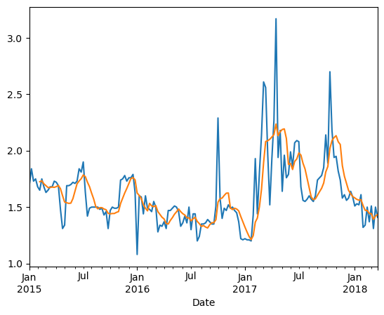

```python
df_tampa['Average Price USD'].plot()
df_tampa['Average Price USD'].rolling(6).mean().plot()
```

## Conclusion

Above is only a glimpse of what is available in the pandas library and it can be overwhelming at first to try and learn. A good bookmark to use is a [pandas cheatsheet](https://pandas.pydata.org/Pandas_Cheat_Sheet.pdf) to learn the basics and build off of that based on what you need to do. Pandas has become the standard python library for data analysis in python - in fact, the name pandas comes from Python Data Analysis Library. Convientely, the geospatial library geopandas is built off of pandas, so almost everything you learn in pandas can be carried over to geopandas.